[figure not shown]

```python
!pip install pyTsetlinMachine
```

```python
!pip install summarytools
```

# **Binary Classification Task Using Tsetlin Machine (TM)**

# executive summary

the aim of this project is to make binary classification using tsetling machine for a telecomunication company called telco and compare it uses with three traditional machine learning algorithm which are decision tree,random forest and logistic regression.the most important metric to access this data is the recall function and the second most important is the f1 score

# 1. introduction

telco is a telecomunication company which aim to classify their data using tsetling machine. in this project we will use tree main metrics to compare the models , those metrics are recall score , f1 score and precision

# dataset

source:https://www.kaggle.com/datasets/blastchar/telco-customer-churn

```python
import pandas as pd
from operator import add
from functools import reduce
import numpy as np
from sklearn.feature_extraction.text import TfidfVectorizer
from summarytools import dfSummary
from sklearn.preprocessing import MinMaxScaler
from sklearn.metrics.pairwise import cosine_similarity
import seaborn as sns
from pyTsetlinMachine.tm    import MultiClassTsetlinMachine
from pyTsetlinMachine.tools  import Binarizer
import pandas as pd
from imblearn.over_sampling import SMOTE
import sklearn.preprocessing
import sklearn.ensemble
import sklearn.linear_model
import sklearn.model_selection
import sklearn.metrics
import matplotlib.pyplot as plt
import seaborn as sns
from sklearn.tree import DecisionTreeClassifier
from sklearn.model_selection import train_test_split

import imblearn.over_sampling
```

# function to fill null value with the best central measure between mean and median

```python
def central_tendancy_calculator(a,column):
#replacing dollar sign and converting to float if necessary
  try:
    # Remove dollar signs and commas, then convert to float
    a[column] = a[column].str.replace(r'[$,]', '', regex=True).astype(float)
  except Exception as e:
    print(f"Error converting column {column}: {e}")
# remove missing value to make calculation
  dataset=pd.DataFrame()
  dataset[column]=a[column].dropna()



#calculate mean
  mean=reduce(add,dataset[column] )/len(dataset[column] )

#calculate interquatile ranges to check the outliers


  Q1 = dataset[column] .quantile(0.25)# Calculate Q1 (25th percentile)
  Q3 = dataset[column] .quantile(0.75)# CalculateQ3 (75th percentile)

  # Calculate the IQR
  IQR = Q3 - Q1

  # Determine the lower and upper bounds for outliers
  lower_bound = Q1 - 1.5 * IQR
  upper_bound = Q3 + 1.5 * IQR

  # Identify outliers

  outliers= (dataset[column]  < lower_bound) | (dataset[column]  > upper_bound)
# calculate median (median is better when the dataset have outliers)
  median= dataset[column].median()
# calculate the mode
  mode=dataset[column].mode()
# calculate skewness
  Skewness=dataset[column].skew()
#calculate variance
  variance=dataset[column].var()
# print result
  # print mean
  print(f"the mean is {mean}")
  # print meddian
  print(f"the median is {median}")
  # print mode
  print(f"the mode is {mode}")
  # print variance
  print(f"the variance is {variance}")
  # print Skewness
  print(f"the skewness is {Skewness}")
  # Print only the outliers
  print("Outliers using IQR method:")
  print( dataset[outliers].count() )

  if int(dataset[outliers].count())==0 and (Skewness>=-0.5 or Skewness<=0.5) :
    print("null value will be fill with the mean")
    a[column].fillna(mean, inplace=True)
  else:
     print("null value will be fill with the median")
     a[column].fillna(median, inplace=True)
```

# function to fill null value with mode

```python
def mode_calculator(a,column):
    # remove missing value to make calculation
  dataset=pd.DataFrame()
  dataset[column]=a[column].dropna()
  # calculate the mode
  mode=dataset[column].mode()
   # print mode
  print(f"the mode is {mode}")
  a[column].fillna(str(mode), inplace=True)
```

# import dataset

```python
df=pd.read_csv("WA_Fn-UseC_-Telco-Customer-Churn.csv")
df
```

|  | customerID | gender | SeniorCitizen | Partner | Dependents | tenure | PhoneService | MultipleLines | InternetService | OnlineSecurity | ... | DeviceProtection | TechSupport | StreamingTV | StreamingMovies | Contract | PaperlessBilling | PaymentMethod | MonthlyCharges | TotalCharges | Churn |
| --- | --- | --- | --- | --- | --- | --- | --- | --- | --- | --- | --- | --- | --- | --- | --- | --- | --- | --- | --- | --- | --- |
| 0 | 7590-VHVEG | Female | 0 | Yes | No | 1 | No | No phone service | DSL | No | ... | No | No | No | No | Month-to-month | Yes | Electronic check | 29.85 | 29.85 | No |
| 1 | 5575-GNVDE | Male | 0 | No | No | 34 | Yes | No | DSL | Yes | ... | Yes | No | No | No | One year | No | Mailed check | 56.95 | 1889.5 | No |
| 2 | 3668-QPYBK | Male | 0 | No | No | 2 | Yes | No | DSL | Yes | ... | No | No | No | No | Month-to-month | Yes | Mailed check | 53.85 | 108.15 | Yes |
| 3 | 7795-CFOCW | Male | 0 | No | No | 45 | No | No phone service | DSL | Yes | ... | Yes | Yes | No | No | One year | No | Bank transfer (automatic) | 42.30 | 1840.75 | No |
| 4 | 9237-HQITU | Female | 0 | No | No | 2 | Yes | No | Fiber optic | No | ... | No | No | No | No | Month-to-month | Yes | Electronic check | 70.70 | 151.65 | Yes |
| ... | ... | ... | ... | ... | ... | ... | ... | ... | ... | ... | ... | ... | ... | ... | ... | ... | ... | ... | ... | ... | ... |
| 7038 | 6840-RESVB | Male | 0 | Yes | Yes | 24 | Yes | Yes | DSL | Yes | ... | Yes | Yes | Yes | Yes | One year | Yes | Mailed check | 84.80 | 1990.5 | No |
| 7039 | 2234-XADUH | Female | 0 | Yes | Yes | 72 | Yes | Yes | Fiber optic | No | ... | Yes | No | Yes | Yes | One year | Yes | Credit card (automatic) | 103.20 | 7362.9 | No |
| 7040 | 4801-JZAZL | Female | 0 | Yes | Yes | 11 | No | No phone service | DSL | Yes | ... | No | No | No | No | Month-to-month | Yes | Electronic check | 29.60 | 346.45 | No |
| 7041 | 8361-LTMKD | Male | 1 | Yes | No | 4 | Yes | Yes | Fiber optic | No | ... | No | No | No | No | Month-to-month | Yes | Mailed check | 74.40 | 306.6 | Yes |
| 7042 | 3186-AJIEK | Male | 0 | No | No | 66 | Yes | No | Fiber optic | Yes | ... | Yes | Yes | Yes | Yes | Two year | Yes | Bank transfer (automatic) | 105.65 | 6844.5 | No |

7043 rows Ã— 21 columns

get some information about the dataset (data type for each column ,number of data each column have ,number of column ,etc)

```python
df.info()
```

```
<class 'pandas.core.frame.DataFrame'>
RangeIndex: 7043 entries, 0 to 7042
Data columns (total 21 columns):
 #   Column            Non-Null Count  Dtype
---  ------            --------------  -----
 0   customerID        7043 non-null   object
 1   gender            7043 non-null   object
 2   SeniorCitizen     7043 non-null   int64
 3   Partner           7043 non-null   object
 4   Dependents        7043 non-null   object
 5   tenure            7043 non-null   int64
 6   PhoneService      7043 non-null   object
 7   MultipleLines     7043 non-null   object
 8   InternetService   7043 non-null   object
 9   OnlineSecurity    7043 non-null   object
 10  OnlineBackup      7043 non-null   object
 11  DeviceProtection  7043 non-null   object
 12  TechSupport       7043 non-null   object
 13  StreamingTV       7043 non-null   object
 14  StreamingMovies   7043 non-null   object
 15  Contract          7043 non-null   object
 16  PaperlessBilling  7043 non-null   object
 17  PaymentMethod     7043 non-null   object
 18  MonthlyCharges    7043 non-null   float64
 19  TotalCharges      7043 non-null   object
 20  Churn             7043 non-null   object
dtypes: float64(1), int64(2), object(18)
memory usage: 1.1+ MB
```

```python
df.describe()
```

|  | SeniorCitizen | tenure | MonthlyCharges |
| --- | --- | --- | --- |
| count | 7043.000000 | 7043.000000 | 7043.000000 |
| mean | 0.162147 | 32.371149 | 64.761692 |
| std | 0.368612 | 24.559481 | 30.090047 |
| min | 0.000000 | 0.000000 | 18.250000 |
| 25% | 0.000000 | 9.000000 | 35.500000 |
| 50% | 0.000000 | 29.000000 | 70.350000 |
| 75% | 0.000000 | 55.000000 | 89.850000 |
| max | 1.000000 | 72.000000 | 118.750000 |

check proportion of churn

```python
display(pd.DataFrame(df["Churn"].value_counts(normalize=True)).T)
```

| Churn | No | Yes |
| --- | --- | --- |
| proportion | 0.73463 | 0.26537 |

# cleaning the dataset

check null values in the dataset

```python
df.isnull().sum()
```

```
customerID          0
gender              0
SeniorCitizen       0
Partner             0
Dependents          0
tenure              0
PhoneService        0
MultipleLines       0
InternetService     0
OnlineSecurity      0
OnlineBackup        0
DeviceProtection    0
TechSupport         0
StreamingTV         0
StreamingMovies     0
Contract            0
PaperlessBilling    0
PaymentMethod       0
MonthlyCharges      0
TotalCharges        0
Churn               0
dtype: int64
```

# customer ID

check if each customer_id

```python
df["customerID"].is_unique
```

```
True
```

# gender

check all values in the gender column

```python
print(set(df["gender"]))
```

```
{'Male', 'Female'}
```

change female to 0 and male to 1

```python
new= {"Female":"No","Male":"Yes"}
df["gender"]=df["gender"].map(new)
print(set(df["gender"]))
```

```
{'Yes', 'No'}
```

# SeniorCitizen

check all values in the column

```python
print(set(df["SeniorCitizen"]))
```

```
{0, 1}
```

# Partner

```python
print(set(df["Partner"]))
```

```
{'Yes', 'No'}
```

# Dependents

check the values in the column

```python
print(set(df["Dependents"]))
```

```
{'Yes', 'No'}
```

# tenure

remove coustomer with less than 1 mounth

```python
df = df[df['tenure'] != 0]
```

# PhoneService

```python
print(set(df["PhoneService"]))
```

```
{'Yes', 'No'}
```

# MultipleLines

```python
print(set(df["MultipleLines"]))
```

```
{'No phone service', 'Yes', 'No'}
```

```python
df['MultipleLines'] = np.where(df['MultipleLines'] == 'Yes', 'Yes', 'No')
print(set(df["MultipleLines"]))
```

```
{'Yes', 'No'}
```

# internetService

```python
print(set(df["InternetService"]))
```

```
{'No', 'Fiber optic', 'DSL'}
```

```python
new= {"No":"no"}
df["InternetService"]=df["InternetService"].map(new).fillna(df["InternetService"])
print(set(df["InternetService"]))
```

```
{'no', 'Fiber optic', 'DSL'}
```

# OnlineSecurity

```python
print(set(df["OnlineSecurity"]))
```

```
{'No internet service', 'Yes', 'No'}
```

```python
df['OnlineSecurity'] = np.where(df['OnlineSecurity'] == 'Yes', 'Yes', 'No')
print(set(df["OnlineSecurity"]))
```

```
{'Yes', 'No'}
```

# OnlineBackup

```python
print(set(df["OnlineBackup"]))
```

```
{'No internet service', 'Yes', 'No'}
```

```python
df['OnlineBackup'] = np.where(df['OnlineBackup'] == 'Yes', 'Yes', 'No')
print(set(df["OnlineBackup"]))
```

```
{'Yes', 'No'}
```

# DeviceProtection

```python
print(set(df["DeviceProtection"]))
```

```
{'No internet service', 'Yes', 'No'}
```

```python
df['DeviceProtection'] = np.where(df['DeviceProtection'] == 'Yes', 'Yes', 'No')
print(set(df["DeviceProtection"]))
```

```
{'Yes', 'No'}
```

# TechSupport

```python
print(set(df["TechSupport"]))
```

```
{'No internet service', 'Yes', 'No'}
```

```python
df['TechSupport'] = np.where(df['TechSupport'] == 'Yes', 'Yes', 'No')
print(set(df["TechSupport"]))
```

```
{'Yes', 'No'}
```

# StreamingTV

```python
print(set(df["StreamingTV"]))
```

```
{'No internet service', 'Yes', 'No'}
```

```python
df['StreamingTV'] = np.where(df['StreamingTV'] == 'Yes', 'Yes', 'No')
print(set(df["StreamingTV"]))
```

```
{'Yes', 'No'}
```

# StreamingMovies

```python
print(set(df["StreamingMovies"]))
```

```
{'No internet service', 'Yes', 'No'}
```

```python
df['StreamingMovies'] = np.where(df['StreamingMovies'] == 'Yes', 'Yes', 'No')
print(set(df["StreamingMovies"]))
```

```
{'Yes', 'No'}
```

# Contract

```python
print(set(df["Contract"]))
```

```
{'Two year', 'Month-to-month', 'One year'}
```

# PaperlessBilling

```python
print(set(df["PaperlessBilling"]))
```

```
{'Yes', 'No'}
```

# PaymentMethod

```python
print(set(df["PaymentMethod"]))
```

```
{'Bank transfer (automatic)', 'Electronic check', 'Mailed check', 'Credit card (automatic)'}
```

remove automatic from the name

```python
new= {"Bank transfer (automatic)":"Bank transfer","Credit card (automatic)":"Credit card"}
df["PaymentMethod"]=df["PaymentMethod"].map(new).fillna(df["PaymentMethod"])
print(set(df["PaymentMethod"]))
```

```
{'Bank transfer', 'Electronic check', 'Mailed check', 'Credit card'}
```

creat a column to check if payement is automatic

```python
new= {"Bank transfer":"Yes","Credit card":"Yes"}
df["PaymentMethod_is_automatic"]=df["PaymentMethod"].map(new).fillna("No")
print(set(df["PaymentMethod_is_automatic"]))
```

```
{'Yes', 'No'}
```

# TotalCharges

```python
df["TotalCharges"]=df["TotalCharges"].astype(float)
```

```python
df["TotalCharges"].isnull().sum()
```

```
0
```

# cleaned dataset

```python
df
```

|  | customerID | gender | SeniorCitizen | Partner | Dependents | tenure | PhoneService | MultipleLines | InternetService | OnlineSecurity | ... | TechSupport | StreamingTV | StreamingMovies | Contract | PaperlessBilling | PaymentMethod | MonthlyCharges | TotalCharges | Churn | PaymentMethod_is_automatic |
| --- | --- | --- | --- | --- | --- | --- | --- | --- | --- | --- | --- | --- | --- | --- | --- | --- | --- | --- | --- | --- | --- |
| 0 | 7590-VHVEG | No | 0 | Yes | No | 1 | No | No | DSL | No | ... | No | No | No | Month-to-month | Yes | Electronic check | 29.85 | 29.85 | No | No |
| 1 | 5575-GNVDE | Yes | 0 | No | No | 34 | Yes | No | DSL | Yes | ... | No | No | No | One year | No | Mailed check | 56.95 | 1889.50 | No | No |
| 2 | 3668-QPYBK | Yes | 0 | No | No | 2 | Yes | No | DSL | Yes | ... | No | No | No | Month-to-month | Yes | Mailed check | 53.85 | 108.15 | Yes | No |
| 3 | 7795-CFOCW | Yes | 0 | No | No | 45 | No | No | DSL | Yes | ... | Yes | No | No | One year | No | Bank transfer | 42.30 | 1840.75 | No | Yes |
| 4 | 9237-HQITU | No | 0 | No | No | 2 | Yes | No | Fiber optic | No | ... | No | No | No | Month-to-month | Yes | Electronic check | 70.70 | 151.65 | Yes | No |
| ... | ... | ... | ... | ... | ... | ... | ... | ... | ... | ... | ... | ... | ... | ... | ... | ... | ... | ... | ... | ... | ... |
| 7038 | 6840-RESVB | Yes | 0 | Yes | Yes | 24 | Yes | Yes | DSL | Yes | ... | Yes | Yes | Yes | One year | Yes | Mailed check | 84.80 | 1990.50 | No | No |
| 7039 | 2234-XADUH | No | 0 | Yes | Yes | 72 | Yes | Yes | Fiber optic | No | ... | No | Yes | Yes | One year | Yes | Credit card | 103.20 | 7362.90 | No | Yes |
| 7040 | 4801-JZAZL | No | 0 | Yes | Yes | 11 | No | No | DSL | Yes | ... | No | No | No | Month-to-month | Yes | Electronic check | 29.60 | 346.45 | No | No |
| 7041 | 8361-LTMKD | Yes | 1 | Yes | No | 4 | Yes | Yes | Fiber optic | No | ... | No | No | No | Month-to-month | Yes | Mailed check | 74.40 | 306.60 | Yes | No |
| 7042 | 3186-AJIEK | Yes | 0 | No | No | 66 | Yes | No | Fiber optic | Yes | ... | Yes | Yes | Yes | Two year | Yes | Bank transfer | 105.65 | 6844.50 | No | Yes |

7032 rows Ã— 22 columns

Exploratory Data AnalysisÂ¶ In this part we will dive deeper into our dataset. We will do some analysis such as:

Univariate

We observe a higher number in the paperless billing category. The churn rate is higher among customers with Paperless Billing.

**Data Frame Summary**  
_  
Dimensions: 7,032 x 22  
Duplicates: 0

No

Variable

Stats / Values

Freqs / (% of Valid)

Graph

Missing

1

**customerID**  
[object]

1. 7590-VHVEG  
2. 0265-PSUAE  
3. 2956-GGUCQ  
4. 6008-NAIXK  
5. 5956-YHHRX  
6. 5365-LLFYV  
7. 5855-EIBDE  
8. 8166-ZZTFS  
9. 0129-KPTWJ  
10. 9128-CPXKI  
11. other

1 (0.0%)  
1 (0.0%)  
1 (0.0%)  
1 (0.0%)  
1 (0.0%)  
1 (0.0%)  
1 (0.0%)  
1 (0.0%)  
1 (0.0%)  
1 (0.0%)  
7,022 (99.9%)

[figure not shown]

0  
(0.0%)

2

**gender**  
[object]

1. Yes  
2. No

3,549 (50.5%)  
3,483 (49.5%)

0  
(0.0%)

3

**SeniorCitizen**  
[int64]

1. 0  
2. 1

5,890 (83.8%)  
1,142 (16.2%)

0  
(0.0%)

4

**Partner**  
[object]

1. No  
2. Yes

3,639 (51.7%)  
3,393 (48.3%)

0  
(0.0%)

5

**Dependents**  
[object]

1. No  
2. Yes

4,933 (70.2%)  
2,099 (29.8%)

0  
(0.0%)

6

**tenure**  
[int64]

Mean (sd) : 32.4 (24.5)  
min < med < max:  
1.0 < 29.0 < 72.0  
IQR (CV) : 46.0 (1.3)

72 distinct values

0  
(0.0%)

7

**PhoneService**  
[object]

1. Yes  
2. No

6,352 (90.3%)  
680 (9.7%)

0  
(0.0%)

8

**MultipleLines**  
[object]

1. No  
2. Yes

4,065 (57.8%)  
2,967 (42.2%)

0  
(0.0%)

9

**InternetService**  
[object]

1. Fiber optic  
2. DSL  
3. no

3,096 (44.0%)  
2,416 (34.4%)  
1,520 (21.6%)

0  
(0.0%)

10

**OnlineSecurity**  
[object]

1. No  
2. Yes

5,017 (71.3%)  
2,015 (28.7%)

0  
(0.0%)

11

**OnlineBackup**  
[object]

1. No  
2. Yes

4,607 (65.5%)  
2,425 (34.5%)

0  
(0.0%)

12

**DeviceProtection**  
[object]

1. No  
2. Yes

4,614 (65.6%)  
2,418 (34.4%)

0  
(0.0%)

13

**TechSupport**  
[object]

1. No  
2. Yes

4,992 (71.0%)  
2,040 (29.0%)

0  
(0.0%)

14

**StreamingTV**  
[object]

1. No  
2. Yes

4,329 (61.6%)  
2,703 (38.4%)

0  
(0.0%)

15

**StreamingMovies**  
[object]

1. No  
2. Yes

4,301 (61.2%)  
2,731 (38.8%)

0  
(0.0%)

16

**Contract**  
[object]

1. Month-to-month  
2. Two year  
3. One year

3,875 (55.1%)  
1,685 (24.0%)  
1,472 (20.9%)

0  
(0.0%)

17

**PaperlessBilling**  
[object]

1. Yes  
2. No

4,168 (59.3%)  
2,864 (40.7%)

0  
(0.0%)

18

**PaymentMethod**  
[object]

1. Electronic check  
2. Mailed check  
3. Bank transfer  
4. Credit card

2,365 (33.6%)  
1,604 (22.8%)  
1,542 (21.9%)  
1,521 (21.6%)

0  
(0.0%)

19

**MonthlyCharges**  
[float64]

Mean (sd) : 64.8 (30.1)  
min < med < max:  
18.2 < 70.3 < 118.8  
IQR (CV) : 54.3 (2.2)

1,584 distinct values

0  
(0.0%)

20

**TotalCharges**  
[float64]

Mean (sd) : 2283.3 (2266.8)  
min < med < max:  
18.8 < 1397.5 < 8684.8  
IQR (CV) : 3393.3 (1.0)

6,530 distinct values

0  
(0.0%)

21

**Churn**  
[object]

1. No  
2. Yes

5,163 (73.4%)  
1,869 (26.6%)

0  
(0.0%)

22

**PaymentMethod_is_automatic**  
[object]

1. No  
2. Yes

3,969 (56.4%)  
3,063 (43.6%)

0  
(0.0%)

```python
dfSummary(df)
```

# important insight from above diagram

- in the second line we can se the gender distribution with male represent by yes and female by no. we observe that 50.5% of the customer are male and 49.5% are female
- the average number of month customer stay in the company is 32 with a std of 24.5 which mean that the data are widely spread awayfrom the mean and that there is a high variability. but half of the customer stay mor than 29 month
- 90% of the customer have Phone Service and around 78% of them have internet service
- more than half of the customer contract are montly-monthly , the average customer pay around 65 montly and half of the customer pay more than 70 monthly
- 26.6% of the customer churn

# churn distribution

in this part shows the visualization of the churk by each charateristic

function to drawnn a bar chart of churn by another metriic

```python
def churn_by(df,b,a="Churn",):
    gender_df=df[b].value_counts()
    gender_churn = df[df[a] == 'Yes'][b].value_counts()
    gender_churn = gender_churn.reindex(gender_df.index, fill_value=0)
    percent_churn = (gender_churn / gender_df) * 100
    gender_churn_df= pd.DataFrame({
        b: gender_df,
        a: gender_churn
    })
    ax=gender_churn_df.plot(kind='bar', color=['blue','red'])
    ax.set_xticklabels(gender_churn_df.index, rotation=0)

    plt.xlabel(b)
    plt.ylabel('Count')
    plt.title('Distribution of Scores by Gender')
    plt.legend(title='bar description')
    plt.show()
    print(f"the churn rate percentage of {b}")
    print(percent_churn)
```

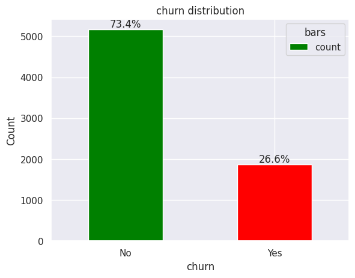

```python
churn_df=df["Churn"].value_counts()
percentages=(churn_df/churn_df.sum())*100
# Plot the distribution

ax=churn_df.plot(kind='bar', color=['green', 'red'])
plt.title('churn distribution')
plt.xlabel('churn')
plt.ylabel('Count')
plt.xticks(rotation=0)
plt.legend(title='bars')
for i, count in enumerate(churn_df):
    percentage = percentages[i]
    ax.text(i, count + 0.1, f'{percentage:.1f}%', ha='center', va='bottom')



plt.show()
```

# churn by gender

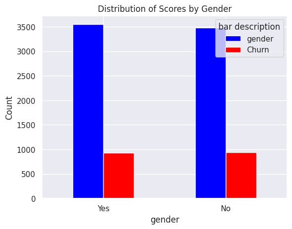

```
the churn rate percentage of gender
gender
Yes    26.204565
No     26.959518
Name: count, dtype: float64
```

```python
churn_by(df,"gender")
```

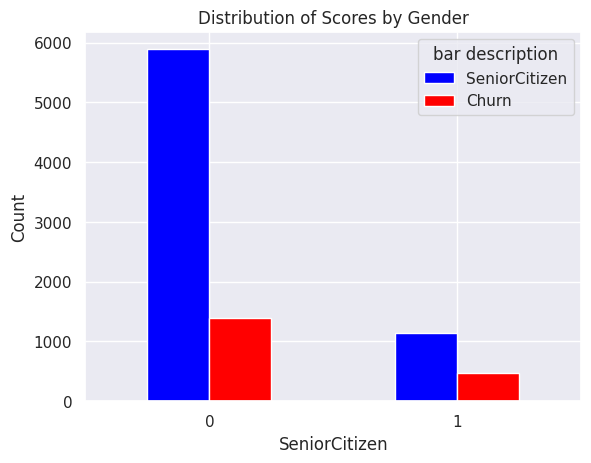

```
the churn rate percentage of SeniorCitizen
SeniorCitizen
0    23.650255
1    41.681261
Name: count, dtype: float64
```

```python
churn_by(df,"SeniorCitizen")
```

# Partner

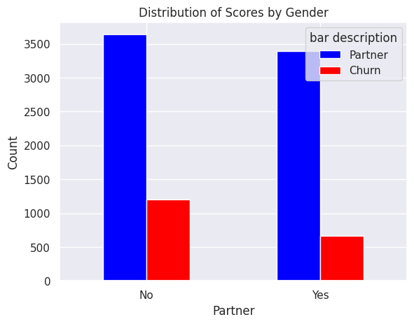

```
the churn rate percentage of Partner
Partner
No     32.976092
Yes    19.717065
Name: count, dtype: float64
```

```python
churn_by(df,"Partner")
```

# Dependents

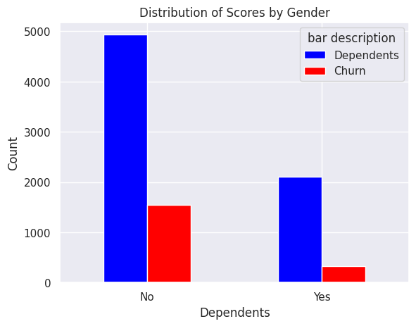

```
the churn rate percentage of Dependents
Dependents
No     31.279140
Yes    15.531205
Name: count, dtype: float64
```

```python
churn_by(df,"Dependents")
```

# tenure

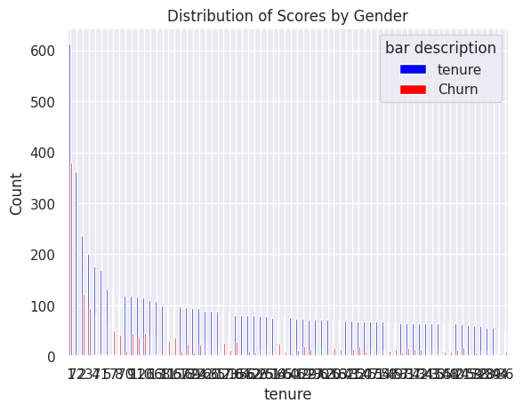

```
the churn rate percentage of tenure
tenure
1     61.990212
72     1.657459
2     51.680672
3     47.000000
4     47.159091
        ...
38    22.033898
28    21.052632
39    25.000000
44    11.764706
36    20.000000
Name: count, Length: 72, dtype: float64
```

```python
churn_by(df,"tenure")
```

# PhoneService

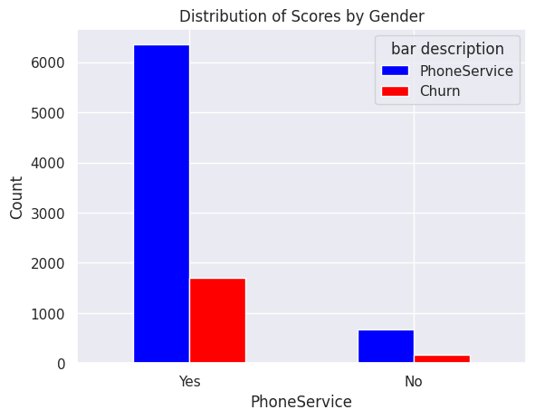

```
the churn rate percentage of PhoneService
PhoneService
Yes    26.747481
No     25.000000
Name: count, dtype: float64
```

```python
churn_by(df,"PhoneService")
```

# MultipleLines

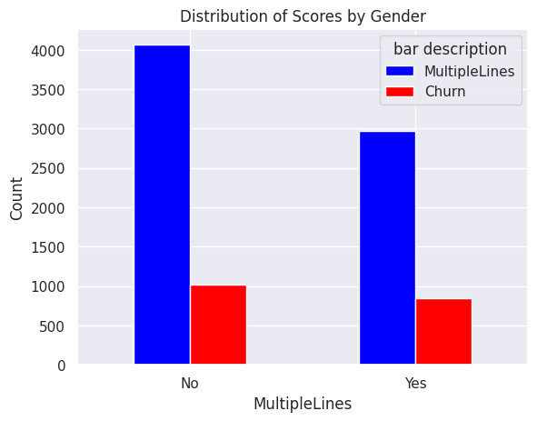

```
the churn rate percentage of MultipleLines
MultipleLines
No     25.067651
Yes    28.648466
Name: count, dtype: float64
```

```python
churn_by(df,"MultipleLines")
```

# InternetService

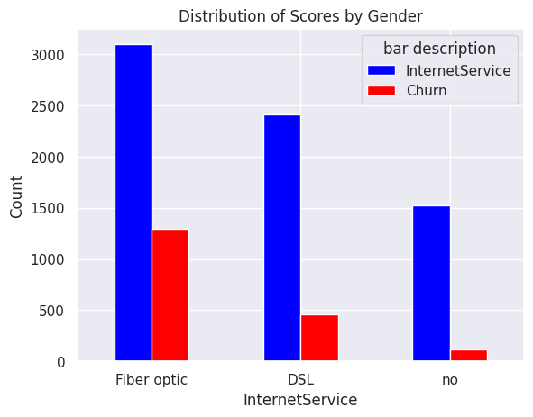

```
the churn rate percentage of InternetService
InternetService
Fiber optic    41.892765
DSL            18.998344
no              7.434211
Name: count, dtype: float64
```

```python
churn_by(df,"InternetService")
```

# OnlineSecurity

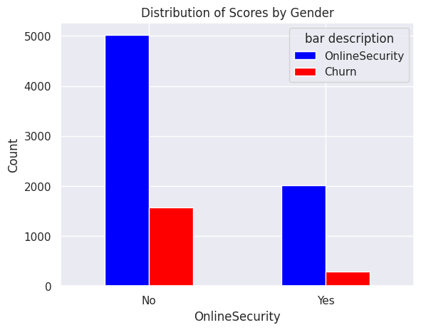

```
the churn rate percentage of OnlineSecurity
OnlineSecurity
No     31.373331
Yes    14.640199
Name: count, dtype: float64
```

```python
churn_by(df,"OnlineSecurity")
```

# OnlineBackup

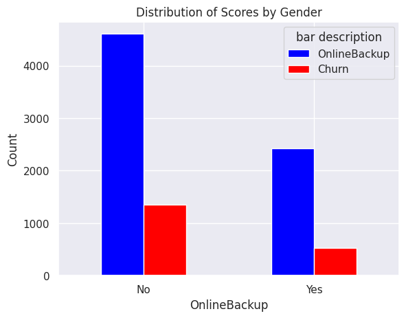

```
the churn rate percentage of OnlineBackup
OnlineBackup
No     29.21641
Yes    21.56701
Name: count, dtype: float64
```

```python
churn_by(df,"OnlineBackup")
```

DeviceProtection

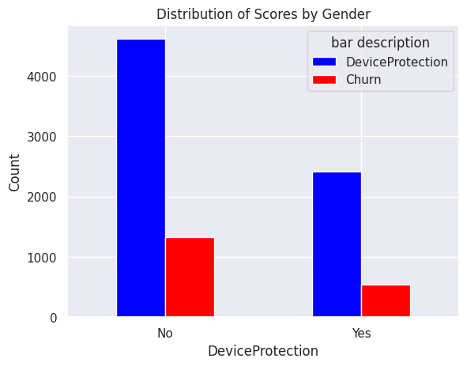

```
the churn rate percentage of DeviceProtection
DeviceProtection
No     28.695275
Yes    22.539289
Name: count, dtype: float64
```

```python
churn_by(df,"DeviceProtection")
```

# TechSupport

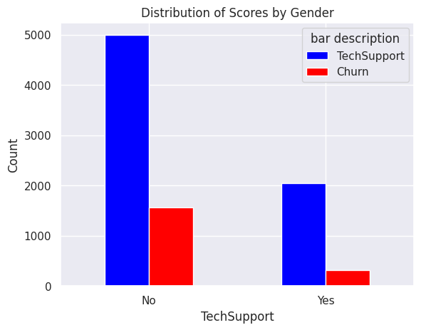

```
the churn rate percentage of TechSupport
TechSupport
No     31.229968
Yes    15.196078
Name: count, dtype: float64
```

```python
churn_by(df,"TechSupport")
```

# StreamingTV

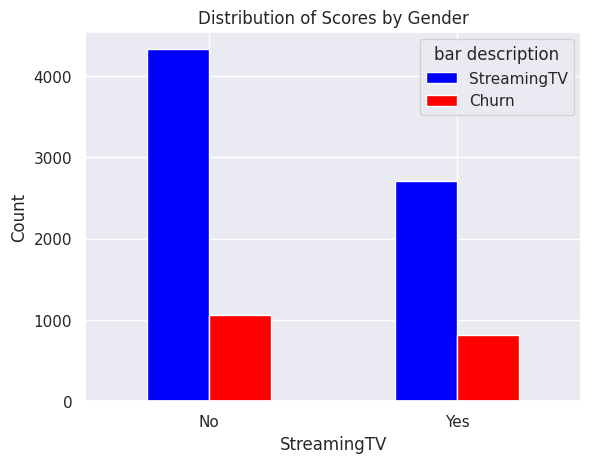

```
the churn rate percentage of StreamingTV
StreamingTV
No     24.370524
Yes    30.114687
Name: count, dtype: float64
```

```python
churn_by(df,"StreamingTV")
```

# StreamingMovies

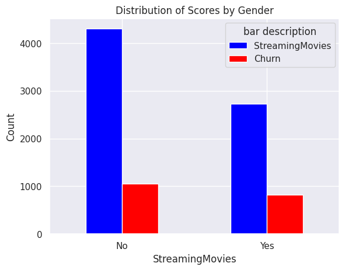

```
the churn rate percentage of StreamingMovies
StreamingMovies
No     24.436178
Yes    29.952398
Name: count, dtype: float64
```

```python
churn_by(df,"StreamingMovies")
```

# Contract

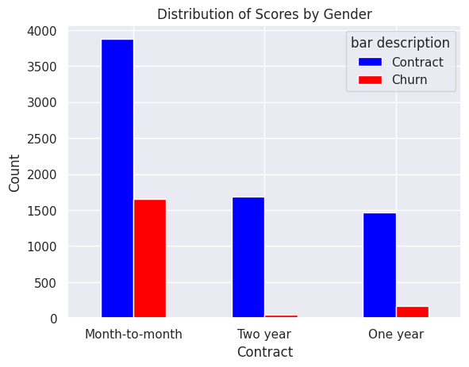

```
the churn rate percentage of Contract
Contract
Month-to-month    42.709677
Two year           2.848665
One year          11.277174
Name: count, dtype: float64
```

```python
churn_by(df,"Contract")
```

# PaperlessBilling

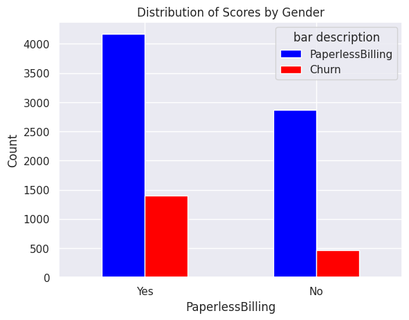

```
the churn rate percentage of PaperlessBilling
PaperlessBilling
Yes    33.589251
No     16.375698
Name: count, dtype: float64
```

```python
churn_by(df,"PaperlessBilling")
```

# PaymentMethod

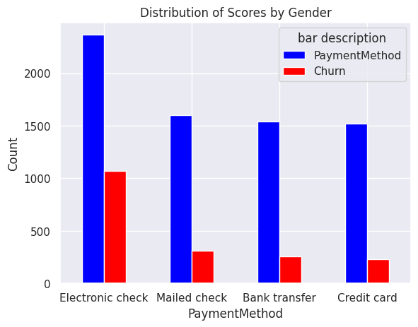

```
the churn rate percentage of PaymentMethod
PaymentMethod
Electronic check    45.285412
Mailed check        19.201995
Bank transfer       16.731518
Credit card         15.253123
Name: count, dtype: float64
```

```python
churn_by(df,"PaymentMethod")
```

# PaymentMethod_is_automatic

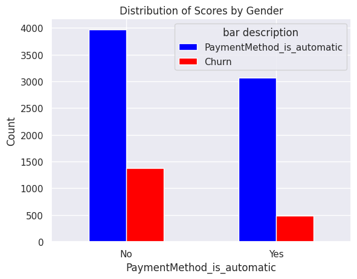

```
the churn rate percentage of PaymentMethod_is_automatic
PaymentMethod_is_automatic
No     34.744268
Yes    15.997388
Name: count, dtype: float64
```

```python
churn_by(df,"PaymentMethod_is_automatic")
```

# MonthlyCharges

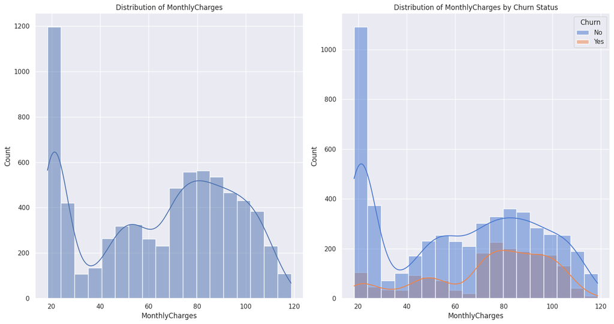

```python
fig,ax = plt.subplots(1,2, figsize = (15,8))
sns.histplot(data = df, x="MonthlyCharges", kde=True, ax=ax[0])
sns.histplot(data = df, x="MonthlyCharges", hue="Churn", kde=True, ax=ax[1], palette="muted")
ax[0].set_title("Distribution of MonthlyCharges")
ax[1].set_title("Distribution of MonthlyCharges by Churn Status")
fig.tight_layout()
plt.show()
```

# **Feature ingeneering**

replace all yes no data to 1 and 0

```python
df.replace({'No': 0, 'Yes': 1}, inplace=True)
df
```

|  | customerID | gender | SeniorCitizen | Partner | Dependents | tenure | PhoneService | MultipleLines | InternetService | OnlineSecurity | ... | TechSupport | StreamingTV | StreamingMovies | Contract | PaperlessBilling | PaymentMethod | MonthlyCharges | TotalCharges | Churn | PaymentMethod_is_automatic |
| --- | --- | --- | --- | --- | --- | --- | --- | --- | --- | --- | --- | --- | --- | --- | --- | --- | --- | --- | --- | --- | --- |
| 0 | 7590-VHVEG | 0 | 0 | 1 | 0 | 1 | 0 | 0 | DSL | 0 | ... | 0 | 0 | 0 | Month-to-month | 1 | Electronic check | 29.85 | 29.85 | 0 | 0 |
| 1 | 5575-GNVDE | 1 | 0 | 0 | 0 | 34 | 1 | 0 | DSL | 1 | ... | 0 | 0 | 0 | One year | 0 | Mailed check | 56.95 | 1889.50 | 0 | 0 |
| 2 | 3668-QPYBK | 1 | 0 | 0 | 0 | 2 | 1 | 0 | DSL | 1 | ... | 0 | 0 | 0 | Month-to-month | 1 | Mailed check | 53.85 | 108.15 | 1 | 0 |
| 3 | 7795-CFOCW | 1 | 0 | 0 | 0 | 45 | 0 | 0 | DSL | 1 | ... | 1 | 0 | 0 | One year | 0 | Bank transfer | 42.30 | 1840.75 | 0 | 1 |
| 4 | 9237-HQITU | 0 | 0 | 0 | 0 | 2 | 1 | 0 | Fiber optic | 0 | ... | 0 | 0 | 0 | Month-to-month | 1 | Electronic check | 70.70 | 151.65 | 1 | 0 |
| ... | ... | ... | ... | ... | ... | ... | ... | ... | ... | ... | ... | ... | ... | ... | ... | ... | ... | ... | ... | ... | ... |
| 7038 | 6840-RESVB | 1 | 0 | 1 | 1 | 24 | 1 | 1 | DSL | 1 | ... | 1 | 1 | 1 | One year | 1 | Mailed check | 84.80 | 1990.50 | 0 | 0 |
| 7039 | 2234-XADUH | 0 | 0 | 1 | 1 | 72 | 1 | 1 | Fiber optic | 0 | ... | 0 | 1 | 1 | One year | 1 | Credit card | 103.20 | 7362.90 | 0 | 1 |
| 7040 | 4801-JZAZL | 0 | 0 | 1 | 1 | 11 | 0 | 0 | DSL | 1 | ... | 0 | 0 | 0 | Month-to-month | 1 | Electronic check | 29.60 | 346.45 | 0 | 0 |
| 7041 | 8361-LTMKD | 1 | 1 | 1 | 0 | 4 | 1 | 1 | Fiber optic | 0 | ... | 0 | 0 | 0 | Month-to-month | 1 | Mailed check | 74.40 | 306.60 | 1 | 0 |
| 7042 | 3186-AJIEK | 1 | 0 | 0 | 0 | 66 | 1 | 0 | Fiber optic | 1 | ... | 1 | 1 | 1 | Two year | 1 | Bank transfer | 105.65 | 6844.50 | 0 | 1 |

7032 rows Ã— 22 columns

# one hot encoding

```python
df_encoded = pd.get_dummies(df, columns=['InternetService', 'Contract','PaymentMethod'],dtype=int)


df_encoded
```

|  | customerID | gender | SeniorCitizen | Partner | Dependents | tenure | PhoneService | MultipleLines | OnlineSecurity | OnlineBackup | ... | InternetService_DSL | InternetService_Fiber optic | InternetService_no | Contract_Month-to-month | Contract_One year | Contract_Two year | PaymentMethod_Bank transfer | PaymentMethod_Credit card | PaymentMethod_Electronic check | PaymentMethod_Mailed check |
| --- | --- | --- | --- | --- | --- | --- | --- | --- | --- | --- | --- | --- | --- | --- | --- | --- | --- | --- | --- | --- | --- |
| 0 | 7590-VHVEG | 0 | 0 | 1 | 0 | 1 | 0 | 0 | 0 | 1 | ... | 1 | 0 | 0 | 1 | 0 | 0 | 0 | 0 | 1 | 0 |
| 1 | 5575-GNVDE | 1 | 0 | 0 | 0 | 34 | 1 | 0 | 1 | 0 | ... | 1 | 0 | 0 | 0 | 1 | 0 | 0 | 0 | 0 | 1 |
| 2 | 3668-QPYBK | 1 | 0 | 0 | 0 | 2 | 1 | 0 | 1 | 1 | ... | 1 | 0 | 0 | 1 | 0 | 0 | 0 | 0 | 0 | 1 |
| 3 | 7795-CFOCW | 1 | 0 | 0 | 0 | 45 | 0 | 0 | 1 | 0 | ... | 1 | 0 | 0 | 0 | 1 | 0 | 1 | 0 | 0 | 0 |
| 4 | 9237-HQITU | 0 | 0 | 0 | 0 | 2 | 1 | 0 | 0 | 0 | ... | 0 | 1 | 0 | 1 | 0 | 0 | 0 | 0 | 1 | 0 |
| ... | ... | ... | ... | ... | ... | ... | ... | ... | ... | ... | ... | ... | ... | ... | ... | ... | ... | ... | ... | ... | ... |
| 7038 | 6840-RESVB | 1 | 0 | 1 | 1 | 24 | 1 | 1 | 1 | 0 | ... | 1 | 0 | 0 | 0 | 1 | 0 | 0 | 0 | 0 | 1 |
| 7039 | 2234-XADUH | 0 | 0 | 1 | 1 | 72 | 1 | 1 | 0 | 1 | ... | 0 | 1 | 0 | 0 | 1 | 0 | 0 | 1 | 0 | 0 |
| 7040 | 4801-JZAZL | 0 | 0 | 1 | 1 | 11 | 0 | 0 | 1 | 0 | ... | 1 | 0 | 0 | 1 | 0 | 0 | 0 | 0 | 1 | 0 |
| 7041 | 8361-LTMKD | 1 | 1 | 1 | 0 | 4 | 1 | 1 | 0 | 0 | ... | 0 | 1 | 0 | 1 | 0 | 0 | 0 | 0 | 0 | 1 |
| 7042 | 3186-AJIEK | 1 | 0 | 0 | 0 | 66 | 1 | 0 | 1 | 0 | ... | 0 | 1 | 0 | 0 | 0 | 1 | 1 | 0 | 0 | 0 |

7032 rows Ã— 29 columns

drop customer id

```python
df_encoded=df_encoded.drop("customerID",axis=1)
```

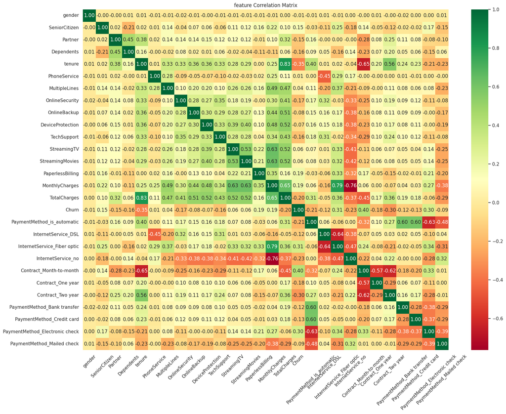

```python
#CORRELATION MATTRIX
correlation_matrix=df_encoded.corr()

plt.figure(figsize=(20, 15))
sns.heatmap(correlation_matrix, annot=True, cmap="RdYlGn", fmt=".2f", linewidths=0)
sns. set(font_scale=1)
plt.title( "feature Correlation Matrix")
plt.xticks(rotation=45)
plt.yticks(rotation=0)




plt.show()
```

correlation of feature with churn

```python
correlation=correlation_matrix.loc["Churn"].drop("Churn").sort_values(ascending=True)
```

```python
correlation
```

```
tenure                           -0.354049
Contract_Two year                -0.301552
InternetService_no               -0.227578
PaymentMethod_is_automatic       -0.210420
TotalCharges                     -0.199484
Contract_One year                -0.178225
OnlineSecurity                   -0.171270
TechSupport                      -0.164716
Dependents                       -0.163128
Partner                          -0.149982
PaymentMethod_Credit card        -0.134687
InternetService_DSL              -0.124141
PaymentMethod_Bank transfer      -0.118136
PaymentMethod_Mailed check       -0.090773
OnlineBackup                     -0.082307
DeviceProtection                 -0.066193
gender                           -0.008545
PhoneService                      0.011691
MultipleLines                     0.040033
StreamingMovies                   0.060860
StreamingTV                       0.063254
SeniorCitizen                     0.150541
PaperlessBilling                  0.191454
MonthlyCharges                    0.192858
PaymentMethod_Electronic check    0.301455
InternetService_Fiber optic       0.307463
Contract_Month-to-month           0.404565
Name: Churn, dtype: float64
```

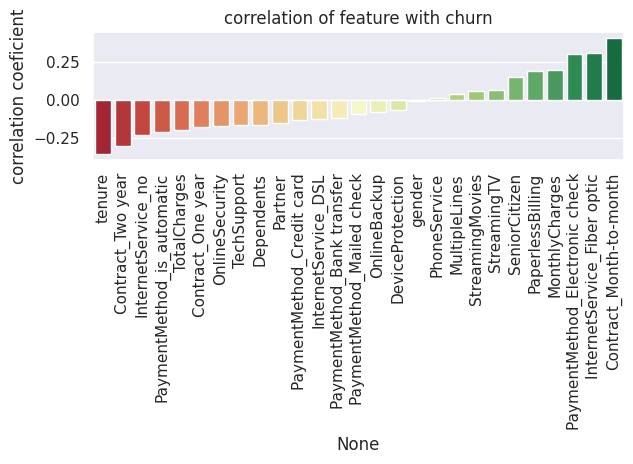

```python
colors= sns.color_palette("RdYlGn", len(correlation))
plt.Figure(figsize=(10,8))
sns.barplot(x=correlation.index,y=correlation.values,palette=colors)
plt.xticks(rotation=90)
plt.ylabel("correlation coeficient")
plt.title("correlation of feature with churn")
plt.tight_layout()
plt.show()
```

# function to show machine performance

```python
def performence(y_test,y_predicted , a):
  print(sklearn.metrics.classification_report(y_test, y_predicted))
  confusion_matrix = sklearn.metrics.confusion_matrix(y_test, y_predicted)

  if a==1:
    cm_display = sklearn.metrics.ConfusionMatrixDisplay(confusion_matrix = confusion_matrix, display_labels = ["retention", "Churn"])

    cm_display.plot()
```

# binarization

```python
y = df_encoded["Churn"].to_numpy()
X = df_encoded.drop("Churn", axis=1).to_numpy()

# Scaling
#scaler = sklearn.preprocessing.StandardScaler()
#X = scaler.fit_transform(X)

pd.DataFrame(X)
```

|  | 0 | 1 | 2 | 3 | 4 | 5 | 6 | 7 | 8 | 9 | ... | 17 | 18 | 19 | 20 | 21 | 22 | 23 | 24 | 25 | 26 |
| --- | --- | --- | --- | --- | --- | --- | --- | --- | --- | --- | --- | --- | --- | --- | --- | --- | --- | --- | --- | --- | --- |
| 0 | 0.0 | 0.0 | 1.0 | 0.0 | 1.0 | 0.0 | 0.0 | 0.0 | 1.0 | 0.0 | ... | 1.0 | 0.0 | 0.0 | 1.0 | 0.0 | 0.0 | 0.0 | 0.0 | 1.0 | 0.0 |
| 1 | 1.0 | 0.0 | 0.0 | 0.0 | 34.0 | 1.0 | 0.0 | 1.0 | 0.0 | 1.0 | ... | 1.0 | 0.0 | 0.0 | 0.0 | 1.0 | 0.0 | 0.0 | 0.0 | 0.0 | 1.0 |
| 2 | 1.0 | 0.0 | 0.0 | 0.0 | 2.0 | 1.0 | 0.0 | 1.0 | 1.0 | 0.0 | ... | 1.0 | 0.0 | 0.0 | 1.0 | 0.0 | 0.0 | 0.0 | 0.0 | 0.0 | 1.0 |
| 3 | 1.0 | 0.0 | 0.0 | 0.0 | 45.0 | 0.0 | 0.0 | 1.0 | 0.0 | 1.0 | ... | 1.0 | 0.0 | 0.0 | 0.0 | 1.0 | 0.0 | 1.0 | 0.0 | 0.0 | 0.0 |
| 4 | 0.0 | 0.0 | 0.0 | 0.0 | 2.0 | 1.0 | 0.0 | 0.0 | 0.0 | 0.0 | ... | 0.0 | 1.0 | 0.0 | 1.0 | 0.0 | 0.0 | 0.0 | 0.0 | 1.0 | 0.0 |
| ... | ... | ... | ... | ... | ... | ... | ... | ... | ... | ... | ... | ... | ... | ... | ... | ... | ... | ... | ... | ... | ... |
| 7027 | 1.0 | 0.0 | 1.0 | 1.0 | 24.0 | 1.0 | 1.0 | 1.0 | 0.0 | 1.0 | ... | 1.0 | 0.0 | 0.0 | 0.0 | 1.0 | 0.0 | 0.0 | 0.0 | 0.0 | 1.0 |
| 7028 | 0.0 | 0.0 | 1.0 | 1.0 | 72.0 | 1.0 | 1.0 | 0.0 | 1.0 | 1.0 | ... | 0.0 | 1.0 | 0.0 | 0.0 | 1.0 | 0.0 | 0.0 | 1.0 | 0.0 | 0.0 |
| 7029 | 0.0 | 0.0 | 1.0 | 1.0 | 11.0 | 0.0 | 0.0 | 1.0 | 0.0 | 0.0 | ... | 1.0 | 0.0 | 0.0 | 1.0 | 0.0 | 0.0 | 0.0 | 0.0 | 1.0 | 0.0 |
| 7030 | 1.0 | 1.0 | 1.0 | 0.0 | 4.0 | 1.0 | 1.0 | 0.0 | 0.0 | 0.0 | ... | 0.0 | 1.0 | 0.0 | 1.0 | 0.0 | 0.0 | 0.0 | 0.0 | 0.0 | 1.0 |
| 7031 | 1.0 | 0.0 | 0.0 | 0.0 | 66.0 | 1.0 | 0.0 | 1.0 | 0.0 | 1.0 | ... | 0.0 | 1.0 | 0.0 | 0.0 | 0.0 | 1.0 | 1.0 | 0.0 | 0.0 | 0.0 |

7032 rows Ã— 27 columns

```python
b = Binarizer()
b.fit(X)
X = b.transform(X)

pd.DataFrame(X)
```

|  | 0 | 1 | 2 | 3 | 4 | 5 | 6 | 7 | 8 | 9 | ... | 89 | 90 | 91 | 92 | 93 | 94 | 95 | 96 | 97 | 98 |
| --- | --- | --- | --- | --- | --- | --- | --- | --- | --- | --- | --- | --- | --- | --- | --- | --- | --- | --- | --- | --- | --- |
| 0 | 0.0 | 0.0 | 1.0 | 0.0 | 0.0 | 0.0 | 0.0 | 0.0 | 0.0 | 0.0 | ... | 1.0 | 0.0 | 0.0 | 1.0 | 0.0 | 0.0 | 0.0 | 0.0 | 1.0 | 0.0 |
| 1 | 1.0 | 0.0 | 0.0 | 0.0 | 1.0 | 1.0 | 1.0 | 1.0 | 1.0 | 1.0 | ... | 1.0 | 0.0 | 0.0 | 0.0 | 1.0 | 0.0 | 0.0 | 0.0 | 0.0 | 1.0 |
| 2 | 1.0 | 0.0 | 0.0 | 0.0 | 1.0 | 0.0 | 0.0 | 0.0 | 0.0 | 0.0 | ... | 1.0 | 0.0 | 0.0 | 1.0 | 0.0 | 0.0 | 0.0 | 0.0 | 0.0 | 1.0 |
| 3 | 1.0 | 0.0 | 0.0 | 0.0 | 1.0 | 1.0 | 1.0 | 1.0 | 1.0 | 1.0 | ... | 1.0 | 0.0 | 0.0 | 0.0 | 1.0 | 0.0 | 1.0 | 0.0 | 0.0 | 0.0 |
| 4 | 0.0 | 0.0 | 0.0 | 0.0 | 1.0 | 0.0 | 0.0 | 0.0 | 0.0 | 0.0 | ... | 0.0 | 1.0 | 0.0 | 1.0 | 0.0 | 0.0 | 0.0 | 0.0 | 1.0 | 0.0 |
| ... | ... | ... | ... | ... | ... | ... | ... | ... | ... | ... | ... | ... | ... | ... | ... | ... | ... | ... | ... | ... | ... |
| 7027 | 1.0 | 0.0 | 1.0 | 1.0 | 1.0 | 1.0 | 1.0 | 1.0 | 1.0 | 1.0 | ... | 1.0 | 0.0 | 0.0 | 0.0 | 1.0 | 0.0 | 0.0 | 0.0 | 0.0 | 1.0 |
| 7028 | 0.0 | 0.0 | 1.0 | 1.0 | 1.0 | 1.0 | 1.0 | 1.0 | 1.0 | 1.0 | ... | 0.0 | 1.0 | 0.0 | 0.0 | 1.0 | 0.0 | 0.0 | 1.0 | 0.0 | 0.0 |
| 7029 | 0.0 | 0.0 | 1.0 | 1.0 | 1.0 | 1.0 | 1.0 | 1.0 | 0.0 | 0.0 | ... | 1.0 | 0.0 | 0.0 | 1.0 | 0.0 | 0.0 | 0.0 | 0.0 | 1.0 | 0.0 |
| 7030 | 1.0 | 1.0 | 1.0 | 0.0 | 1.0 | 1.0 | 0.0 | 0.0 | 0.0 | 0.0 | ... | 0.0 | 1.0 | 0.0 | 1.0 | 0.0 | 0.0 | 0.0 | 0.0 | 0.0 | 1.0 |
| 7031 | 1.0 | 0.0 | 0.0 | 0.0 | 1.0 | 1.0 | 1.0 | 1.0 | 1.0 | 1.0 | ... | 0.0 | 1.0 | 0.0 | 0.0 | 0.0 | 1.0 | 1.0 | 0.0 | 0.0 | 0.0 |

7032 rows Ã— 99 columns

# **COMPARING ALGORITHM**

in this part we will compare basic setting performance of tsetlin machine with logistic regression , random forest,decision tree

The key metrics to compare this algorithm are recall_score,f1_score and precision_score. we have to maximise the Recall as we want the model to focuse correctly detecte the potential churn. and secondly focuse on f1 score to balance precison and recall

# split data

```python
# Split to train and test
X_train, X_test, y_train, y_test = train_test_split(X, y, test_size=0.2, shuffle=True, stratify=y)
```

# **testling machine**

```
TRAIN PERFOMANCE

              precision    recall  f1-score   support

           0       0.84      0.91      0.87      4130
           1       0.67      0.51      0.58      1495

    accuracy                           0.80      5625
   macro avg       0.75      0.71      0.73      5625
weighted avg       0.79      0.80      0.79      5625

TEST PERFOMANCE

              precision    recall  f1-score   support

           0       0.82      0.89      0.85      1033
           1       0.60      0.47      0.53       374

    accuracy                           0.78      1407
   macro avg       0.71      0.68      0.69      1407
weighted avg       0.76      0.78      0.77      1407
```

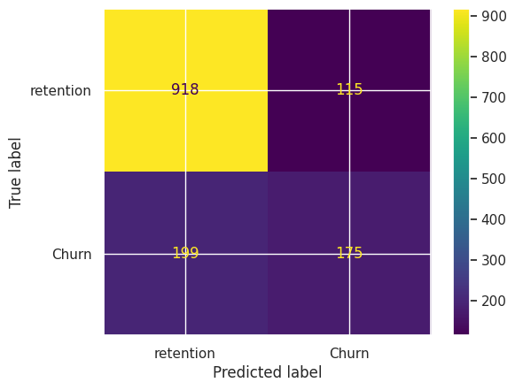

```python
tm= MultiClassTsetlinMachine(number_of_clauses=100,T=100,s=6)
tm.fit(X_train,y_train,epochs=10 )
y_trpred = tm.predict(X_train)
y_pred= tm.predict(X_test)
print("TRAIN PERFOMANCE\n")
performence(y_train,y_trpred,0)
print("TEST PERFOMANCE\n")
performence(y_test,y_pred,1)
```

apply SMOTE to balance the data

```python
churn_original=y_train.sum()/len(y_train)
smote= SMOTE()
X_train, y_train=smote.fit_resample(X_train,y_train)
print(f"original churn percentage: {churn_original}")
print(f"original churn percentage: {y_train.sum()/len(y_train)}")
```

```
original churn percentage: 0.2657777777777778
original churn percentage: 0.5
```

```
TRAIN PERFOMANCE

              precision    recall  f1-score   support

           0       0.76      0.82      0.79      4130
           1       0.80      0.73      0.77      4130

    accuracy                           0.78      8260
   macro avg       0.78      0.78      0.78      8260
weighted avg       0.78      0.78      0.78      8260

TEST PERFOMANCE

              precision    recall  f1-score   support

           0       0.87      0.80      0.83      1033
           1       0.55      0.66      0.60       374

    accuracy                           0.77      1407
   macro avg       0.71      0.73      0.72      1407
weighted avg       0.78      0.77      0.77      1407
```

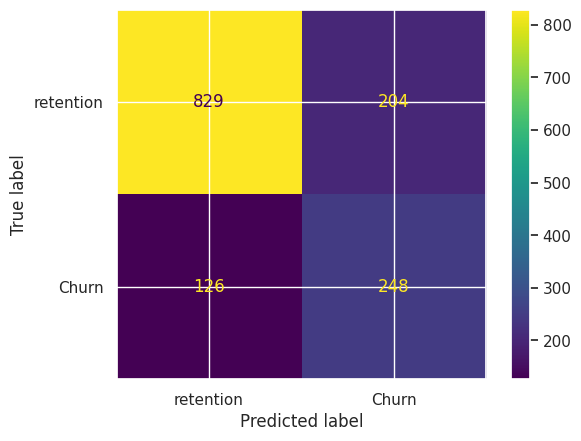

```python
tm= MultiClassTsetlinMachine(number_of_clauses=100,T=100,s=6)
tm.fit(X_train,y_train,epochs=10)
y_trpred = tm.predict(X_train)
y_pred= tm.predict(X_test)
print("TRAIN PERFOMANCE\n")
performence(y_train,y_trpred,0)
print("TEST PERFOMANCE\n")
performence(y_test,y_pred,1)
```

# **logistic regression**

```
TRAIN PERFOMANCE

              precision    recall  f1-score   support

           0       0.82      0.75      0.78      4130
           1       0.77      0.83      0.80      4130

    accuracy                           0.79      8260
   macro avg       0.79      0.79      0.79      8260
weighted avg       0.79      0.79      0.79      8260

TEST PERFOMANCE

              precision    recall  f1-score   support

           0       0.91      0.73      0.81      1033
           1       0.52      0.80      0.63       374

    accuracy                           0.75      1407
   macro avg       0.71      0.76      0.72      1407
weighted avg       0.80      0.75      0.76      1407
```

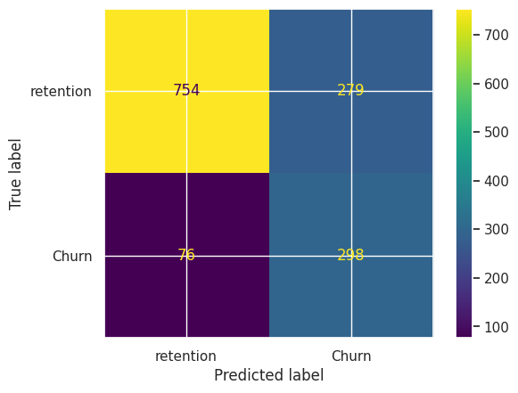

```python
lr= sklearn.linear_model.LogisticRegression(max_iter=10000)
lr.fit(X_train,y_train )
y_trpred = lr.predict(X_train)
y_pred= lr.predict(X_test)
print("TRAIN PERFOMANCE\n")
performence(y_train,y_trpred,0)
print("TEST PERFOMANCE\n")
performence(y_test,y_pred,1)
```

# **random forest**

```
TRAIN PERFOMANCE

              precision    recall  f1-score   support

           0       0.99      0.98      0.99      4130
           1       0.98      0.99      0.99      4130

    accuracy                           0.99      8260
   macro avg       0.99      0.99      0.99      8260
weighted avg       0.99      0.99      0.99      8260

TEST PERFOMANCE

              precision    recall  f1-score   support

           0       0.83      0.88      0.85      1033
           1       0.59      0.49      0.54       374

    accuracy                           0.78      1407
   macro avg       0.71      0.69      0.69      1407
weighted avg       0.76      0.78      0.77      1407
```

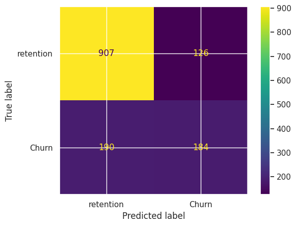

```python
rf= sklearn.ensemble.RandomForestClassifier( )
rf.fit(X_train,y_train )
y_trpred = rf.predict(X_train)
y_pred= rf.predict(X_test)
print("TRAIN PERFOMANCE\n")
performence(y_train,y_trpred,0)
print("TEST PERFOMANCE\n")
performence(y_test,y_pred,1)
```

# **decision tree**

```
TRAIN PERFOMANCE

              precision    recall  f1-score   support

           0       0.99      0.99      0.99      4130
           1       0.99      0.99      0.99      4130

    accuracy                           0.99      8260
   macro avg       0.99      0.99      0.99      8260
weighted avg       0.99      0.99      0.99      8260

TEST PERFOMANCE

              precision    recall  f1-score   support

           0       0.82      0.80      0.81      1033
           1       0.48      0.51      0.50       374

    accuracy                           0.72      1407
   macro avg       0.65      0.66      0.65      1407
weighted avg       0.73      0.72      0.73      1407
```

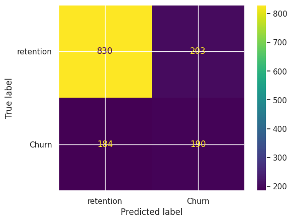

```python
dtc= DecisionTreeClassifier(random_state=42)
dtc.fit(X_train,y_train )
y_trpred = dtc.predict(X_train)
y_pred= dtc.predict(X_test)
print("TRAIN PERFOMANCE\n")
performence(y_train,y_trpred,0)
print("TEST PERFOMANCE\n")
performence(y_test,y_pred,1)
```